სმკმ: მეოთხე შეხვედრა

# სოციალურ მეცნიერებათა კვლევის მეთოდები

დავით სიჭინავა  
10 ოქტომბერი, 2019 წ.

მეოთხე შეხვედრა

### დღევანდელი შეხვედრის გეგმა

- ლექცია: კვლევის გეგმა, კონცეპტუალიზაცია და ოპერაციონალიზაცია
- სემინარი

### ისევ: სამეცნიერო რევოლუცია

[figure not shown]

### ისევ: სამეცნიერო რევოლუცია

- აღიარებული (დამკვიდრებული) და რევოლუციური მეცნიერება
- პარადიგმები
  - პარადიგმისადმი ერთგულება

### ცნება

- ცნება წარმოადგენს ამა თუ იმ ფენომენის განზოგადებულ, ლინგვისტურ შესატყვისს
- ცნება არის *სიმბოლო* და არა - კონკრეტული *ფენომენი*
- მეცნიერები ამა თუ იმ ფენომენს *სახელს არქმევენ*, რათა სხვებისთვის აღწერა გაუადვილდეთ
- ცნებები ამა თუ იმ ფენომენის კლასიფიკაციის თუ დაჯგუფებისთვისაა საჭირო
- ცნებების მეშვეობით ხდება თეორიის აგება

### (ცნების) განსაზღვრება

- კონცეპტუალიზაცია: ცნების აღწერა **სხვა ცნებების** მეშვეობით

### კონცეპტუალიზაცია

- ცნებების (კონცეპტების) განვითარების და ჩამოყალიბების პროცესი
- ჩამოვაყალიბოთ ამა თუ იმ ცნების *სიტყვიერი* და *გასაგები* განმარტება, თუ რას მოვიაზრებთ ამ სიტყვის ქვეშ

### მაგალითი: სოციალური სტატუსი

სიტყვიერი განსაზღვრება: საზოგადოებაში პიროვნების მდგომარეობა მისი მნიშვნელობის მიხედვით (Oxford Living Dictionary)

- რას მოიცავს სოციალური სტატუსი? *Hollingshead, A. (1975): Four factor index of social status*
  - განათლება
  - საქმიანობა
  - სქესი (გენდერი)
  - ოჯახური მდგომარეობა

### კონცეპტუალიზაცია

- კონცეპტუალიზაცია უნდა მოიცავდეს ფენომენის ყველა უნიკალურ თვისებას
- განმარტებაში არ გამოვიყენოთ *განმარტებითი ტერმინები*
- განმარტება უნდა იყოს *პოზიტიური*
- კონცეპტუალიზაცია უნდა მოიცავდეს *მკაფიო ტერმინებს*

### კონცეპტუალიზაცია

- თვისებრივი და რაოდენობრივი კვლევების კონცეპტუალიზაცია
- თვისებრივი კონცეპტუალიზაცია:
  - როგორც წესი, ჩვენ მონაცემთა მოგროვების პროცესში ვფიქრობთ კონცეფციების შესახებ
  - კვლევისას, ჩვენ კონცეფციებს ვუკავშირებთ *კონკრეტულ მნიშვნელობებს* და ვცდილობთ, დავადგინოთ კავშირები ამ იდეებს შორის.

### კონცეპტუალიზაცია

რაოდენობრივი:

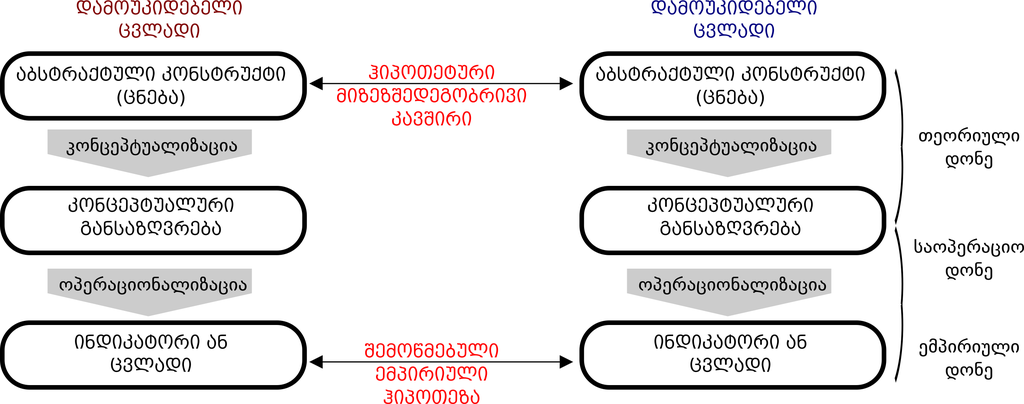

### ოპერაციონალიზაცია (ოპერაციული განსაზღვრება)

- როგორ *გავზომავთ* ამა თუ იმ ცნებას

### მაგალითი: სოციალური სტატუსი

- განათლება:
  - განათლების მიღწეული დონე
- საქმიანობა:
  - ISCO-88 კოდები
- სქესი:
  - მამაკაცი
  - ქალი
- ოჯახური მდგომარეობა:
  - დასაოჯახებელი
  - დაოჯახებული
  - განქორწინებული
  - ქვრივი
  - სხვა

### თეორიის როლი

- კონკრეტული კლასიფიკაციის (ad hoc) თეორიები
- ტაქსონომია
- კონცეპტუალური სტრუქტურა
- თეორიული სისტემა

### მაგალითი: ლიპსეტის და როკანის დაპირისპირებების თეორია (1964)

- თეორიული სისტემა: ტალკოტ-პარსონსის სოციალური სისტემების მოდელი
  - სიტუაციური ობიექტების კლასიფიკაცია
  - ობიექტებისადმი დამოკიდებულება
  - პასუხი სისტემის გამოწვევებისადმი

### მაგალითი: ლიპსეტის და როკანის დაპირისპირებების თეორია (1964)

- კონცეპტუალური სტრუქტურა: ნებისმიერ დასავლურ საზოგადოებაში, პოლიტიკური პარტიებისადმი მიკუთვნება ეფუძნება სოციალურ დაპირისპირებებს, რომლებიც ე.წ. დიდი რევოლუციების შედეგად აღმოცენდნენ

### მაგალითი: ლიპსეტის და როკანის დაპირისპირებების თეორია (1964)

- ტაქსონომია: დაპირისპირებები
  - ცენტრი-პერიფერია
  - ქალაქი-სოფელი
  - დამსაქმებელი-დასაქმებული
  - ეკლესია-სახელმწიფო

### მაგალითი: ლიპსეტის და როკანის დაპირისპირებების თეორია (1964)

- კონკრეტული კლასიფიკაცია:
  - ტერიტორიულ ერთეულში საქალაქო მოსახლეობის წილი
  - მემარცხენე პოლიტიკური პარტიის მიერ მიღებული ხმები
  - რელიგიური კუთვნილება

### აქსიომატური თეორია

- ცნებების, განსაზღვრებების, დებულებების და ურთიერთკავშირების ერთობლიობა, რომლებიც ცნებების დასაკავშირებლად და თეორიების დასამტკიცებლად გამოიყენება

### მოდელები

- აბსტრაქცია, განზოგადება, რომელიც ფენომენის *ჩვენეულ* აღწერას, გამარტივებულ ხატს წარმოადგენს

### კავშირი ემპირიასა და თეორიას შორის

- კვლევა → თეორიას
- თეორია → კვლევას

### კვლევის გეგმა (პროგრამა)

- დაზვერვითი კვლევა
  - შესწავლის პირველი ეტაპი
- აღწერითი კვლევა
  - ფენომენის შესახებ ამომწურავი, ოღონდ - აღწერილობითი ტიპის ინფორმაციის მიღება
- ანალიტიკური კვლევა
  - ფენომენის მამოძრავებელი ძალების, მიზეზების გამოაშკარავება; პროგნოზირება, ურთიერთკავშირების დადგენა

### კვლევის გეგმა (პროგრამა)

[figure not shown]

### კვლევის გეგმა (პროგრამა)

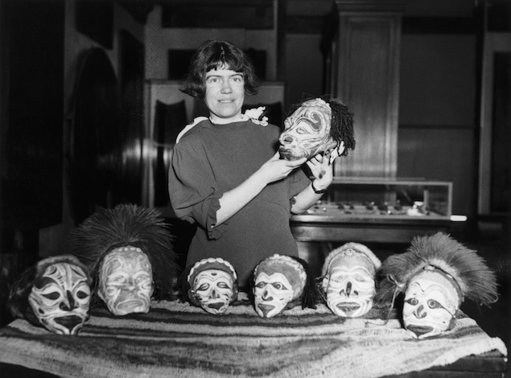

### რას ვიკვლევთ?

- კვლევის პრობლემა და მისი აქტუალობა
- კვლევის ობიექტი
- კვლევის საგანი
- კვლევის მიზანი

### თანმიმდევრობა

- გამოკვლევის პროგრამა
- ველი
- ინფორმაციის დამუშავება
- ინფორმაციის ანალიზი
- ანგარიში და პრეზენტაცია

### სემინარი:

- ჯგუფებში გაეცანით ჩემს მიერ დარიგებულ სტატიებს და მოამზადეთ მცირე პრეზენტაცია
- რას იკვლევენ ავტორები?
  - რა ფენომენს?
  - რა თეორიებს ეყრდნობიან ავტორები?
  - რომელი კონკრეტული ჯგუფი აინტერესებთ მათ?
  - რა კითხვებზე ცდილობენ პასუხის გაცემას?
  - არის თუ არა კვლევა კონცენტრირებული რომელიმე კონკრეტულ არეალზე?
- რა მიდგომას იყენებენ ავტორები და რატომ?
  - თვისებრივს თუ რაოდენობრივს? დაასაბუთეთ
- თქვენი აზრით, რამდენად ამომწურავად მოახერხეს ავტორებმა დასმული საკითხის შესწავლა?

### დავალება:

- წაიკითხეთ ამ ორი ანგარიშიდან ერთ-ერთი: [პირველი ანგარიში](http://crrc.ge/uploads/tinymce/documents/STOP%20Policy%20Document_GEO.pdf), [მეორე ანგარიში](http://awdb.ge/files/PPAG_Anti%20western%20propaganda%20in%20social%20media_geo.pdf)
- მოამზადეთ ამ ნაშრომის შესახებ კრიტიკული შეფასება, სადაც აღწერთ:
  - რა მიზანს ისახავდა ეს კვლევა?
  - თქვენი აზრით, რა ძირითადი კონცეფციები იყო განხილული ამ კვლევაში?
  - რა ტიპის მეთოდები იყო გამოყენებული - რაოდენობრივი თუ თვისებრივი? პასუხი დაასაბუთეთ.
  - თქვენი აზრით, რა იყო ამ კვლევის ერთი, ყველაზე მნიშვნელოვანი შედეგი?
  - თქვენი აზრით, რა საჭიროებდა უფრო ღრმად შესწავლას?
- თქვენი ტექსტი უნდა იყოს Microsoft Word-ის დოკუმენტის მაქსიმუმ გვერდნახევარი, 12 ზომის Sylfaen **ქართული(!)** შრიფტით და სტრიქონებს შორის 1.5 დაშორებით. დოკუმენტი დაასათაურეთ, მიაწერეთ თქვენი სახელი, გვარი და ელექტრონული ფოსტის მისამართი.
- დავალება ატვირთეთ 16 ოქტომბრის 23:59-მდე, [ამ ბმულზე](https://www.dropbox.com/request/FDCxORi0tFU8mDf1TQRP)

[figure not shown]